# LM: Uncertainty in point estimates

2018-05-15

## The Linear Model: LM

- 2.0 Introduction
- 2.1 Point estimates
- 2.2 Uncertainty in point estimates
- 2.3 Tests
- 2.4 Assumptions and Outliers
- 2.5 Let's practice more

## You will learn in this session

- that point estimates are random variables with estimated means and variances
- that estimates are not necessarily independent from each other
- that estimates for \(\beta\) are Gaussian and the estimate of the error variance is gamma distributed
- what 95% Confidence Intervals are
- what the parametric bootstrap is
- that there are 3 main ways to get 95% CI for LM
- that boundaries for 95% CI on \(\widehat{\beta}\) are given by the Student distribution
- what likelihood profiling is
- what statistical coverage is
- what 95% CI on the mean response are
- what 95% Prediction Intervals are

## Introduction

## Summary of point estimates

```r
set.seed(123L)
Alien <- data.frame(humans_eaten = sample(1:12))
Alien$size <- rnorm(n = 12, mean = 50 + 1.5*Alien$humans_eaten, sd = sqrt(25))

mod_stats <- lm(size ~ humans_eaten, data = Alien)
c(coef(mod_stats), sigma2_error <- summary(mod_stats)$sigma^2)
```

```
##  (Intercept) humans_eaten
##    51.139816     1.319579    29.286641
```

```r
mod_spaMM_ML   <- fitme(size ~ humans_eaten, data = Alien, method = "ML")
mod_spaMM_REML <- fitme(size ~ humans_eaten, data = Alien, method = "REML")
c(mod_spaMM_ML$fixef, sigma2 = mod_spaMM_REML$phi)  ## in LM fixef are same for ML and REML but not in LMM
```

```
##  (Intercept) humans_eaten       sigma2
##    51.139816     1.319579    29.286641
```

### Those are point estimates. Estimates are random variables!

```r
sigma2_resid <- mod_spaMM_ML$phi ## stored for later (but it is not an estimate!)
```

## Theoretical distributions of point estimates

## Covariances of the estimates

```r
XTX <- crossprod(model.matrix(mod_stats))
## XTX/sigma2_error is the Hessian (matrix of second derivative) of Lik(X)
## the inverse of the Hessian gives the covariance matrix
sigma2_error * solve(XTX)
```

```
##              (Intercept) humans_eaten
## (Intercept)    11.093425   -1.3312110
## humans_eaten   -1.331211    0.2048017
```

```r
vcov(mod_stats)
```

```
##              (Intercept) humans_eaten
## (Intercept)    11.093425   -1.3312110
## humans_eaten   -1.331211    0.2048017
```

```r
vcov(mod_spaMM_REML)  ## don't use the ML fit here!
```

```
##              (Intercept) humans_eaten
## (Intercept)    11.093425   -1.3312110
## humans_eaten   -1.331211    0.2048017
## attr(,"class")
## [1] "vcov.HLfit" "matrix"
## with additional attribute(s): beta_v_cov
```

## The estimates of \(\beta\) are Gaussian (asymptotically)

```r
candidate_intercept_u <- seq(from = 30, to = 70,  by = 0.1)
candidate_slope_u     <- seq(from =  0, to = 2.5, by = 0.1)

candidates <- expand.grid(candidate_intercept = candidate_intercept_u, candidate_slope = candidate_slope_u)

candidates$d <- dmvnorm(x = candidates[, 1:2], mean = coef(mod_stats), sigma = vcov(mod_stats), log = FALSE)
```

Note: we will reuse the candidate values repeatedly.

## Multivariate density of the estimates for \(\beta\)

```r
library(rgl)  ## to make interactive plots!
with(data = candidates, plot3d(candidate_intercept, candidate_slope, d))
```

[interactive chart not shown]

You must enable Javascript to view this page properly.

## Same plot with `graphics`

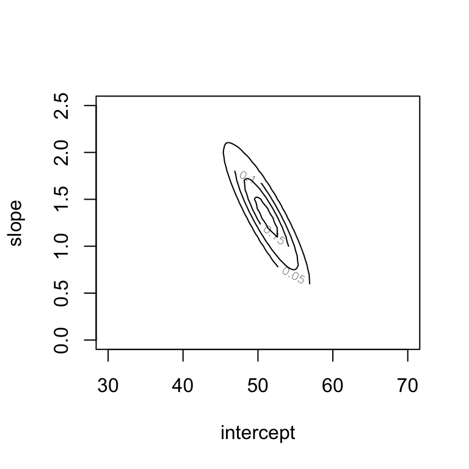

```r
contour(x = candidate_intercept_u, y = candidate_slope_u,
        z = matrix(candidates$d, nrow = length(candidate_intercept_u)),
        nlevels = 5, xlab = "intercept", ylab = "slope")
```

## The estimate of \(\sigma^2\) is Gamma (asymptotically)

\(\widehat{\sigma}^2\) follows a \(\Gamma\) distribution with mean = \(\texttt{error variance}\) and var = \(2 ( \texttt{error variance})^2 / (N-K)\).

[for \(\Gamma\), mean = \(\texttt{shape} \times \texttt{scale}\) and var = \(\texttt{shape} \times \texttt{scale}^2\)]

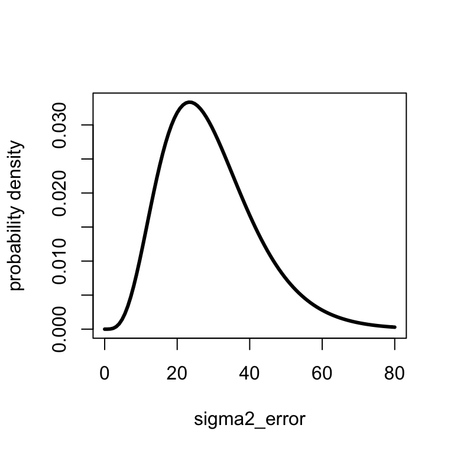

```r
curve(dgamma(x, shape = mod_stats$df.residual/2, scale = 2*sigma2_error/mod_stats$df.residual),
    from = 0, to = 80, xlab = "sigma2_error", ylab = "probability density", lwd = 3)
```

## Comparing theoretical distributions to the reality

## A simulation function for the generating Aliens

```r
simulate_Aliens
```

```
## function (N = 12, intercept = 50, slope = 1.5, sigma2 = 25)
## {
##     Aliens <- data.frame(humans_eaten = sample(1:N))
##     Aliens$size <- stats::rnorm(n = N, mean = intercept + slope *
##         Aliens$humans_eaten, sd = sqrt(sigma2))
##     return(Aliens)
## }
## <environment: namespace:LM2GLMM>
```

```r
head(Alien)
```

```
##   humans_eaten     size
## 1            4 58.30458
## 2            9 57.17469
## 3            5 54.06574
## 4            8 59.77169
## 5           11 72.62041
## 6            1 53.29907
```

```r
set.seed(123L)
head(simulate_Aliens())
```

```
##   humans_eaten     size
## 1            4 58.30458
## 2            9 57.17469
## 3            5 54.06574
## 4            8 59.77169
## 5           11 72.62041
## 6            1 53.29907
```

## Distribution of the estimates for \(\beta\)

```r
new_beta_estimates <- t(replicate(1000, coef(update(mod_stats, data = simulate_Aliens()))))
```

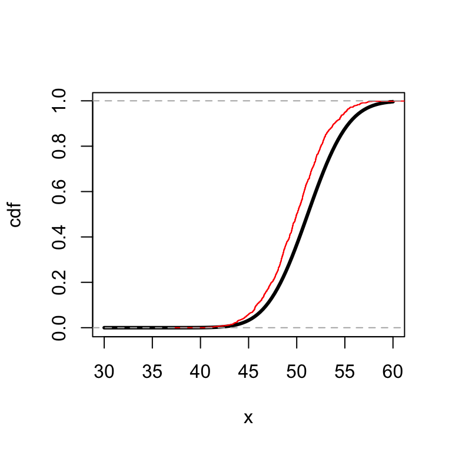

```r
curve(pnorm(x, mean = coef(mod_stats)[1],
    sd = sqrt(vcov(mod_stats)[[1]])),
    from = 30, to = 60, ylab = "cdf", lwd = 3)
plot(ecdf(new_beta_estimates[, 1]), col = "red",
     add = TRUE)
```

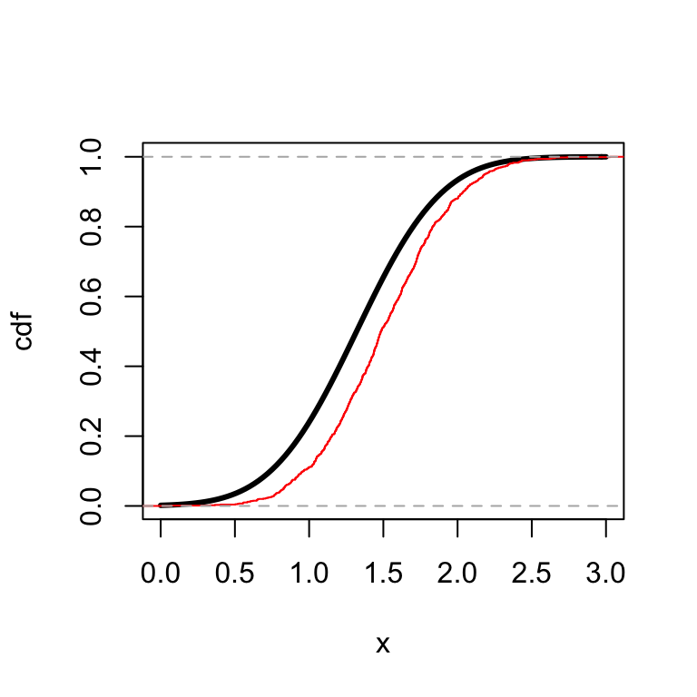

```r
curve(pnorm(x, mean = coef(mod_stats)[2],
    sd = sqrt(vcov(mod_stats)[[4]])),
    from = 0, to = 3, ylab = "cdf", lwd = 3)
plot(ecdf(new_beta_estimates[, 2]), col = "red",
     add = TRUE)
```

## Distribution of the estimate for \(\sigma^2\)

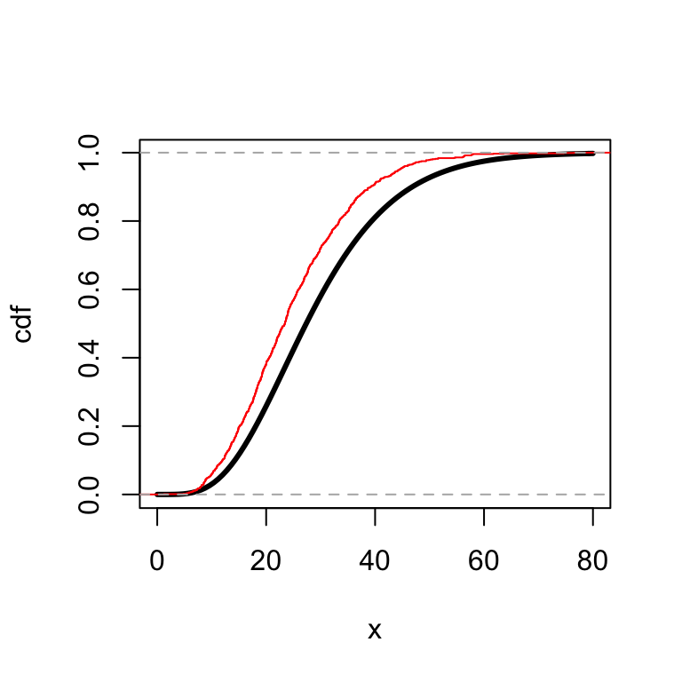

```r
new_sigma2_error <- t(replicate(1000, summary(update(mod_stats, data = simulate_Aliens()))$sigma^2))
curve(pgamma(x, shape = mod_stats$df.residual/2, scale = 2*summary(mod_stats)$sigma^2/mod_stats$df.residual),
    from = 0, to = 80, ylab = "cdf", lwd = 3)
plot(ecdf(new_sigma2_error), col = "red", add = TRUE)
```

## Confidence intervals

## What is a confidence interval?

For any interval-construction method applied to samples from a distribution characterized by some parameter value P, the coverage is by definition the probability that the interval contains P.

By definition, an interval is an exact confidence interval with given coverage X if its coverage is X for any parameter P.

Most methods for interval computation are approximate, i.e. the actual coverage differs from the given coverage X.

Since the observed data correspond to a randomly selected set, then it is likely that the true value of the parameter lies within the confidence interval. Yet, you never know for sure (when using real data).

Note: a confidence interval is also the set of parameter values not rejected by a given test.

## Confidence intervals: asymptotic

## CI for \(\widehat{\beta}\) with known variance

\(\widehat{\beta}\sim \mathcal{N}(\beta, \sigma_{\widehat{\beta}})\)

\(z = \frac{\widehat{\beta} - \beta}{\sigma_{\widehat{\beta}}}\sim \mathcal{N}(0, 1)\)

95% CI for \(z = [\mathrm{Q}0.025_{\mathcal{N}}; \ \mathrm{Q}0.975_{\mathcal{N}} ]\)

```r
c(Q0.025_N = qnorm(0.025), Q0.975_N = qnorm(0.975))
```

```
##  Q0.025_N  Q0.975_N
## -1.959964  1.959964
```

95% CI for \(\widehat{\beta} = [\widehat{\beta} + \mathrm{Q0.025}_{\mathcal{N}} \times \sigma_{\widehat{\beta}}; \ \widehat{\beta} + \mathrm{Q0.975}_{\mathcal{N}} \times \sigma_{\widehat{\beta}}]\)

## CI for \(\widehat{\beta}\) with estimated variance

\(\widehat{\beta}\sim \mathcal{N}(\beta, \sigma_{\widehat{\beta}})\)

\(t = \frac{\widehat{\beta} - \beta}{\widehat{\sigma_{\widehat{\beta}}}}\sim \mathcal{t}_{N - K}\) (\(t\) = Student's t distribution)

95% CI for \(t = [\mathrm{Q}0.025_{\mathcal{t}_{N - K}}; \ \mathrm{Q}0.975_{\mathcal{t}_{N - K}}]\)

```r
c(Qt_0.025 = qt(0.025, df = 10), Qt_0.975 = qt(0.975, df = 10))  ## with N-K = 10 (also try with 1000)
```

```
##  Qt_0.025  Qt_0.975
## -2.228139  2.228139
```

95% CI for \(\widehat{\beta} =\)

\([\widehat{\beta} + \mathrm{Q}0.025_{\mathcal{t}_{N - K}} \times \widehat{\sigma_{\widehat{\beta}}}; \ \widehat{\beta} + \mathrm{Q}0.975_{\mathcal{t}_{N - K}} \times \widehat{\sigma_{\widehat{\beta}}}]\)

## Computing 95% CI for estimates

```r
confint(mod_stats)
```

```
##                   2.5 %    97.5 %
## (Intercept)  43.7185999 58.561032
## humans_eaten  0.3112346  2.327924
```

```r
quantile_min <- qt(0.025, mod_stats$df.residual)
quantile_max <- qt(0.975, mod_stats$df.residual)
cbind(coef(mod_stats) + quantile_min * sqrt(diag(vcov(mod_stats))),
      coef(mod_stats) + quantile_max * sqrt(diag(vcov(mod_stats))))
```

```
##                    [,1]      [,2]
## (Intercept)  43.7185999 58.561032
## humans_eaten  0.3112346  2.327924
```

## Testing the coverage of the 95% CI

```r
set.seed(1L)
mean(replicate(5000, sum(findInterval(confint(update(mod_stats, data = simulate_Aliens()))[1, ], 50)) == 1))
```

```
## [1] 0.9528
```

```r
mean(replicate(5000, sum(findInterval(confint(update(mod_stats, data = simulate_Aliens()))[2, ], 1.5)) == 1))
```

```
## [1] 0.9462
```

The coverage of the CI based on the Student distribution is great!

(note: asymptotically this method is perfect for LM)

## Confidence intervals: bootstrap

## The aim of the bootstrap

The aim of the boostrap is to approximate the distribution of a statistic, in cases where parameters are not known (as usual) and where this distribution is not known analytically.

The data (non-parametric bootstrap), or estimates derived from it (parametric bootstrap) are used as approximations to the unknown distribution using a resampling procedure.

- When we simulate, we decide what the parameter values really are.
- When we fit, we estimate what the unknown parameter values are.
- Bootstrap: something in the middle; we simulate new observations considering the estimates as the true parameter values.
  - Non-parametric bootstrap: bootstrap samples that are iid (independent and identically distributed) from the point of view of the empirical distribution.
  - Parametric bootstrap: bootstrap samples that are iid from the point of view of the estimates.

## Computing 95% CI for estimates (np. boot.)

```r
  res_sim <- do.call("rbind", sapply(1:100, function(i) {
    newdata <- Alien[sample(1:nrow(Alien), replace = TRUE), ]
    t(coef(update(mod_stats, data = newdata)))
    }, simplify = FALSE))
  (confint_npboot <- rbind(quantile(res_sim[, 1], probs = c(0.025, 0.975)),
                           quantile(res_sim[, 2], probs = c(0.025, 0.975))))
```

```
##            2.5%     97.5%
## [1,] 44.5165315 56.773607
## [2,]  0.2393982  2.128688
```

There is no theoretical reason to expect non-parametric bootstrap to produce good CI!

## Testing the coverage of the 95% CI (np. boot.)

```r
CInpboot <- function(rep = 100){
  data <- simulate_Aliens()
  mod <- update(mod_stats, data = data)
  res_sim <- do.call("rbind", sapply(1:rep, function(i) {
    newdata <- data[sample(1:nrow(data), replace = TRUE), ]
    t(coef(update(mod, data = newdata)))
  }, simplify = FALSE))
  rbind(quantile(res_sim[, 1], probs = c(0.025, 0.975)),
        quantile(res_sim[, 2], probs = c(0.025, 0.975)))
}
set.seed(1L)
mean(replicate(5000, sum(findInterval(CInpboot()[1, ], 50)) == 1))
```

```
## [1] 0.8728
```

```r
mean(replicate(5000, sum(findInterval(CInpboot()[2, ], 1.5)) == 1))
```

```
## [1] 0.8866
```

Indeed, the non-parametric bootstrap sucks!

## How to get CI using from parametric bootstrap

We have

- one real parameter (out of one possible): \(a\)
- one estimate (out of many possible): \(\widehat{a}\)
- bootstrap: a set of \(a^*\)

We assume that

- the difference \(\widehat{a} - a\) follows the same distribution than the difference \(a^* - \widehat{a}\)

Thus

\(\widehat{a} - a \sim \widehat{a} - (a^* - \widehat{a}) = 2\widehat{a} - a^*\)

Example using the bootstrap expectation:

If \(a = 1\) and \(\widehat{a} = 2\) then we expect \(\overline{a^*} = 3\);

Reciprocally,

if \(\overline{a^*} = 3\) and \(\widehat{a} = 2\), we infer \(\widehat{a} - a \sim 2\widehat{a} - \overline{a^*} = 2 \times 2 - 3 = 1\) so \(a \sim \widehat{a} - 1 = 1\).

## Computing 95% CI for estimates (param. boot.)

```r
confint(mod_stats)  ## asymptotic (for comparison)
```

```
##                   2.5 %    97.5 %
## (Intercept)  43.7185999 58.561032
## humans_eaten  0.3112346  2.327924
```

We now longer use the knowledge of the asymptotic distribution:

```r
res_sim <- do.call("rbind", sapply(1:100, function(i) {
    newYs <- simulate(mod_stats)
    t(coef(lm(as.matrix(newYs) ~ humans_eaten, data = Alien)))
    }, simplify = FALSE))
(confint_boot <- rbind(quantile(2*coef(mod_stats)[1] - res_sim[, 1], probs = c(0.025, 0.975)),
                       quantile(2*coef(mod_stats)[2] - res_sim[, 2], probs = c(0.025, 0.975))))
```

```
##          2.5%     97.5%
## [1,] 45.93363 56.737380
## [2,]  0.47853  2.013208
```

## Testing the coverage of the 95% CI (param. boot.)

```r
CIboot <- function(rep = 100){
  data <- simulate_Aliens()
  mod <- update(mod_stats, data = data)
  newYs <- simulate(mod, nsim = rep)
  res_sim <- t(coef(lm(as.matrix(newYs) ~ humans_eaten, data = data)))
  rbind(quantile(2*coef(mod)[1] - res_sim[, 1], probs = c(0.025, 0.975)),
        quantile(2*coef(mod)[2] - res_sim[, 2], probs = c(0.025, 0.975)))
}
set.seed(1L)
mean(replicate(5000, sum(findInterval(CIboot()[1, ], 50)) == 1))
```

```
## [1] 0.9032
```

```r
mean(replicate(5000, sum(findInterval(CIboot()[2, ], 1.5)) == 1))
```

```
## [1] 0.904
```

That is far from perfect, but already better…

## CI using the package boot

### 1. Define the functions computing statistics and new data

```r
refit <- function(data, i = c(1, 2)) coef(lm(size ~ humans_eaten, data = data))[i]
newY  <- function(data, ...) { ## the second argument is necessary even if we don't use it
  data[, "size"] <- simulate(mod_stats, nsim = 1)
  return(data)
}
refit(Alien) ## the original fit
```

```
##  (Intercept) humans_eaten
##    51.139816     1.319579
```

```r
refit(data = newY(Alien)) ## fit on data simulated by parametric bootstrap
```

```
##  (Intercept) humans_eaten
##    51.186824     1.224873
```

## CI using the package boot

### 2. Run the parameteric bootstrap using `boot`

```r
library(boot)
(sim.boot1 <- boot(data = Alien, statistic = refit, ran.gen = newY,
                  i = 1, R = 100, sim = "parametric")) ## change i to 2 for the slope!
```

```
##
## PARAMETRIC BOOTSTRAP
##
##
## Call:
## boot(data = Alien, statistic = refit, R = 100, sim = "parametric",
##     ran.gen = newY, i = 1)
##
##
## Bootstrap Statistics :
##     original     bias    std. error
## t1* 51.13982 -0.1796924    3.214261
```

```r
sim.boot2 <- boot(data = Alien, statistic = refit, ran.gen = newY,
                  i = 2, R = 100, sim = "parametric")
```

Note: the bias (= mean bootstrap - estimate) will be accounted for at the next step.

## CI using the package boot

### 3. Compute the CI using `boot.ci`

```r
boot.ci(sim.boot1, type = "basic")  ## alternative: "perc", "norm", "stud"
```

```
## BOOTSTRAP CONFIDENCE INTERVAL CALCULATIONS
## Based on 100 bootstrap replicates
##
## CALL :
## boot.ci(boot.out = sim.boot1, type = "basic")
##
## Intervals :
## Level      Basic
## 95%   (43.98, 57.58 )
## Calculations and Intervals on Original Scale
## Some basic intervals may be unstable
```

```r
(confint_boot2 <- rbind(boot.ci(sim.boot1, type = "basic")$basic[, 4:5],
                        boot.ci(sim.boot2, type = "basic")$basic[, 4:5]))
```

```
##
## [1,] 43.9814732 57.576152
## [2,]  0.3638193  2.230722
```

## Testing the coverage of the 95% CI (using boot)

```r
CIboot2a <- function(rep = 100, i){
  data <- simulate_Aliens()
  mod <- update(mod_stats, data = data)
  newData  <- function(data, ...) {
    data[, "size"] <- simulate(mod, nsim = 1)
    return(data)
  }
  sim.boot <- boot(data = data, statistic = refit, ran.gen = newData, i = i, R = rep, sim = "parametric")
  boot.ci(sim.boot, type = "basic")$basic[, 4:5]
}
set.seed(1L)
c(mean(replicate(500, sum(findInterval(CIboot2a(i = 1), 50)) == 1)),
  mean(replicate(500, sum(findInterval(CIboot2a(i = 2), 1.5)) == 1)))
```

```
## [1] 0.914 0.926
```

Note: extremelly slow…

## Testing the coverage of the 95% CI (using boot)

```r
CIboot2b <- function(rep = 100, i){
  data <- simulate_Aliens()
  mod <- update(mod_stats, data = data)
  newYs <- simulate(mod, nsim = rep)
  res_sim <- t(coef(lm(as.matrix(newYs) ~ humans_eaten, data = data)))
  boot.ci(boot.out = list(R = nrow(res_sim)),
          t0 = coef(mod)[[i]],
          t  = res_sim[, i, drop = FALSE],
          type = "basic")$basic[, 4:5]
}
set.seed(1L)
c(mean(replicate(5000, sum(findInterval(CIboot2b(i = 1), 50)) == 1)),
  mean(replicate(5000, sum(findInterval(CIboot2b(i = 2), 1.5)) == 1)))
```

```
## [1] 0.9206 0.9234
```

Note 1: we bypass `boot()` to save time (a single call to `simulate()` is more efficient).

Note 2: there are many variations of the parametric bootstrap!

## Testing the coverage of the 95% CI (using boot)

```r
CIboot2c <- function(rep = 100, i){
  data <- simulate_Aliens()
  mod <- update(mod_stats, data = data)
  newYs <- simulate(mod, nsim = rep)
  res_sim <- t(coef(lm(as.matrix(newYs) ~ humans_eaten, data = data)))
  boot.ci(boot.out = list(R = nrow(res_sim)),
          t0 = coef(mod)[[i]],
          t  = res_sim[, i, drop = FALSE],
          var.t0 = vcov(mod)[i, i],
          var.t = rep(var(res_sim[, i]), nrow(res_sim)),
          type = "stud")$student[, 4:5]
}
set.seed(1L)
c(mean(replicate(5000, sum(findInterval(CIboot2c(i = 1), 50)) == 1)),
  mean(replicate(5000, sum(findInterval(CIboot2c(i = 2), 1.5)) == 1)))
```

```
## [1] 0.9220 0.9262
```

Note: here it accounts for the uncertainty in the estimation of the variance (but not great either…).

## Confidence intervals: likelihood profiling

## Computing the likelihood for specific parameters

```r
logLik(lm(size ~ 0 + offset(50 + 1.5 * humans_eaten), data = Alien))
```

```
## 'log Lik.' -36.291 (df=1)
```

```r
logLik(fitme(size ~ 0 + offset(50 + 1.5 * humans_eaten), fixed = list(phi = 25), data = Alien))
```

```
##      p_v
## -36.2912
```

Note: `spaMM` allows the fixation of the variance in addition to the fixation of the other parameters.

## Likelihood profiling 1 parameter: \(\sigma^2\)

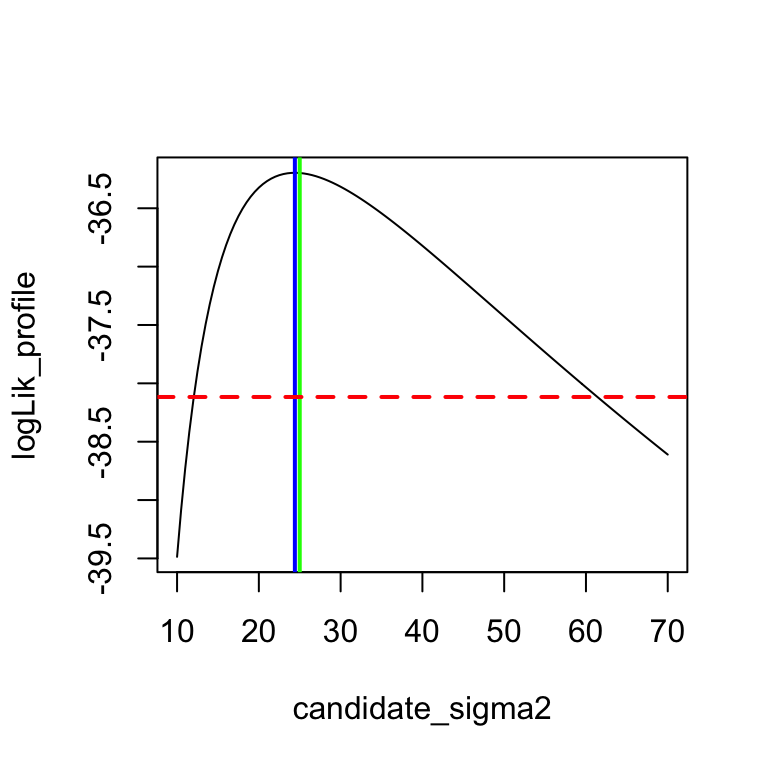

```r
mod_spaMM_allfix <- fitme(size ~ humans_eaten, fixed = list(phi = 25), data = Alien)
candidate_sigma2 <- seq(10, 70, 0.5)
logLik_profile <- sapply(candidate_sigma2, function(sigma2) ## for each sigma2 we re-estimate other parameters
  logLik(update(mod_spaMM_allfix, fixed = list(phi = sigma2))))
plot(logLik_profile ~ candidate_sigma2, type = "l")
abline(v = 25, col = "green", lwd = 2)
abline(v = mod_spaMM_ML$phi, col = "blue", lwd = 2)
abline(h = logLik(mod_stats) - 0.5*qchisq(0.95, 1), col = "red", lty = 2, lwd = 2)
```

## Likelihood profiling 1 parameter: intercept

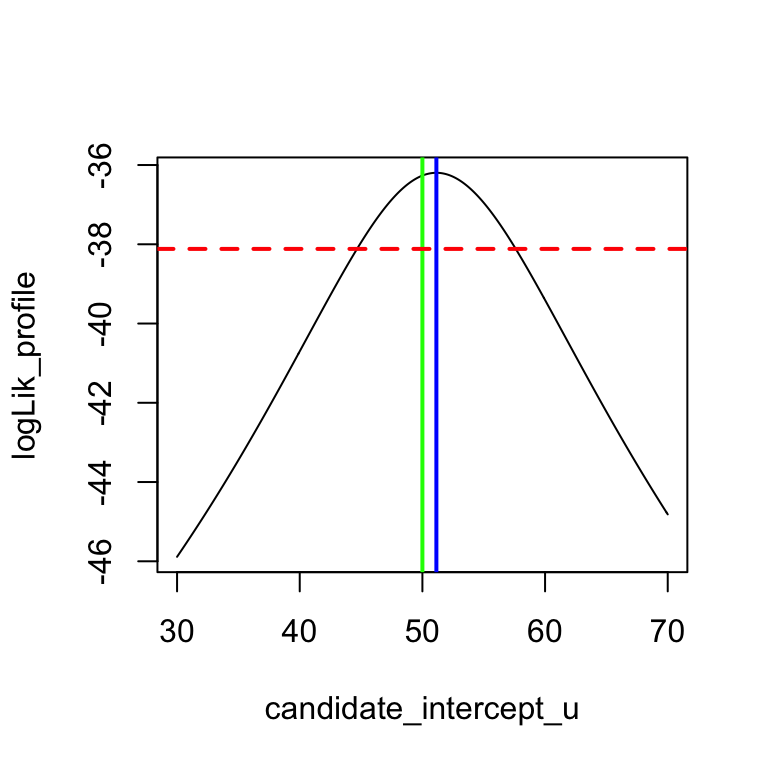

```r
logLik_profile <- sapply(candidate_intercept_u, function(intercept)
  logLik(lm(size ~ 0 + humans_eaten + offset(rep(intercept, nrow(Alien))), data = Alien)))
plot(logLik_profile ~ candidate_intercept_u, type = "l")
abline(v = 50, col = "green", lwd = 2)
abline(v = coef(mod_stats)[1], col = "blue", lwd = 2)
abline(h = logLik(mod_stats) - 0.5*qchisq(0.95, 1), col = "red", lty = 2, lwd = 2)
```

## Likelihood profiling 2 parameters: plot

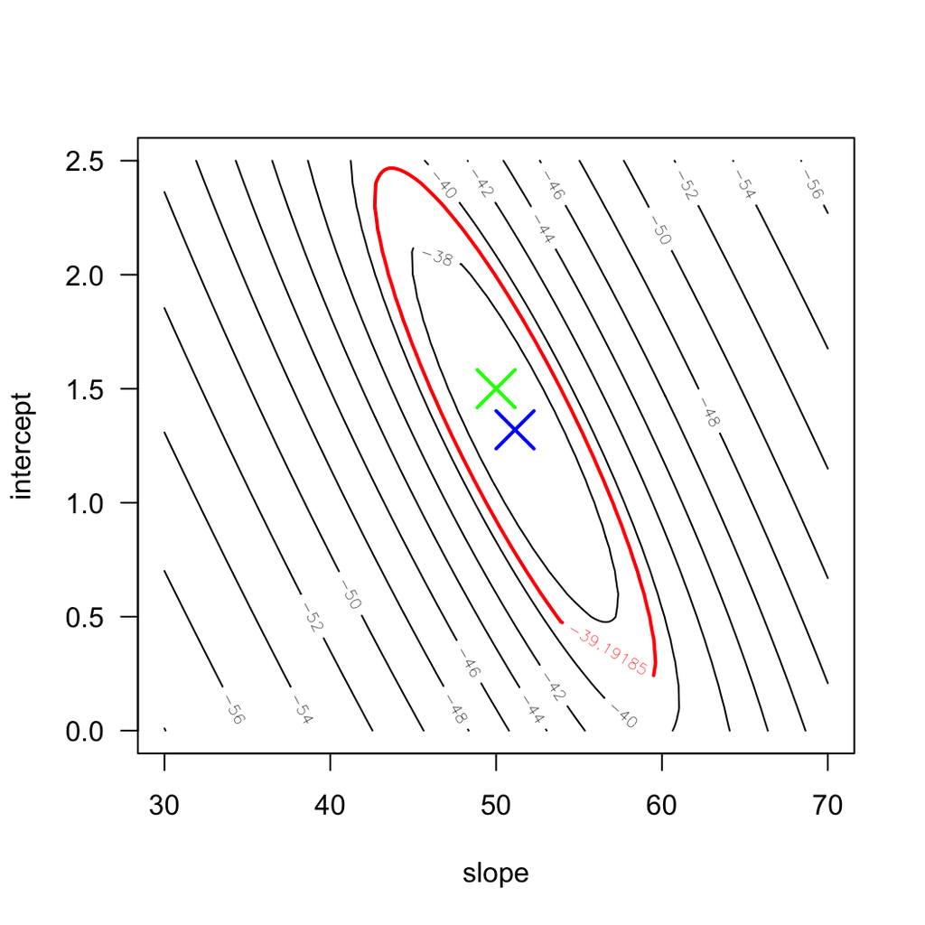

## Likelihood profiling 2 parameters: code

```r
candidates$logLik <- NA

for (i in 1:nrow(candidates)) {
  mod_temp <- lm(size ~  0 + offset(candidates[i, 1] + candidates[i, 2] * humans_eaten), data = Alien)
  candidates[i, "logLik"] <- logLik(mod_temp)
}

par(las = 1)
with(candidates, contour(candidate_intercept_u, candidate_slope_u,
                         matrix(candidates$logLik, nrow = length(candidate_intercept_u)),
                         nlevels = 15, xlab = "slope", ylab = "intercept"))
points(mod_spaMM_ML$fixef["(Intercept)"], mod_spaMM_ML$fixef["humans_eaten"],
       col = "blue", pch = 4, lwd = 2, cex = 3)
points(50, 1.5, col = "green", pch = 4, lwd = 2, cex = 3)

limit <- c(logLik(mod_stats) - 0.5*qchisq(0.95, df = 2))
with(candidates, contour(candidate_intercept_u, candidate_slope_u,
  matrix(candidates$logLik, nrow = length(candidate_intercept_u)),
  levels = limit, add = TRUE, col = "red", lwd = 2))
```

## Confidence intervals by likelihood profiling

- Benefit: not based on SE, so works well even if error is not gaussian or if SE is badly estimated.
- Cost: uses the chi-squared distribution, which is an asymptotic approximation, so it needs a lot of observations.

```r
where.is.limit.inter <- function(intercept, model_ref) {
  logLik_mod <- logLik(lm(size ~ 0 + humans_eaten + offset(rep(intercept, nrow(model_ref$model))),
                            data = model_ref$model))[[1]]
  logLik_goal <- logLik(model_ref)[[1]] - 0.5*qchisq(0.95, df = 1)
  return(abs(logLik_mod - logLik_goal))}
CI_intercept <- function(model_ref) {
  lwr <- optimise(where.is.limit.inter, interval = c(coef(model_ref)[1] - 10, coef(model_ref)[1]),
                  model_ref = model_ref)
  upr <- optimise(where.is.limit.inter, interval = c(coef(model_ref)[1], coef(model_ref)[1] + 10),
                  model_ref = model_ref)
  return(c(lwr = lwr$minimum, upr = upr$minimum))}
rbind("using Student" = confint(mod_stats)[1, ], "using np. boot." = confint_npboot[1, ],
      "using param. boot. 1" = confint_boot[1, ], "using param. boot. 2" = confint_boot2[1, ],
      "using profile" = CI_intercept(mod_stats))
```

```
##                         2.5 %   97.5 %
## using Student        43.71860 58.56103
## using np. boot.      44.51653 56.77361
## using param. boot. 1 45.93363 56.73738
## using param. boot. 2 43.98147 57.57615
## using profile        44.67026 57.60937
```

## Same for the slope

```r
where.is.limit.slope <- function(slope, model_ref) {
  logLik_mod <- logLik(lm(size ~ 1 + offset(slope * humans_eaten),
                            data = model_ref$model))[[1]]
  logLik_goal <- logLik(model_ref)[[1]] - 0.5*qchisq(0.95, df = 1)
  return(abs(logLik_mod - logLik_goal))
}

CI_slope <- function(model_ref) {
  lwr <- optimise(where.is.limit.slope, interval = c(coef(model_ref)[2] - 1, coef(model_ref)[2]),
                  model_ref = model_ref)
  upr <- optimise(where.is.limit.slope, interval = c(coef(model_ref)[2], coef(model_ref)[2] + 1),
                  model_ref = model_ref)
  return(c(lwr = lwr$minimum, upr = upr$minimum))
}

rbind("using Student" = confint(mod_stats)[2, ], "using np. boot." = confint_npboot[2, ],
      "using param. boot. 1" = confint_boot[2, ], "using param. boot. 2" = confint_boot2[2, ],
      "using profile" = CI_slope(mod_stats))
```

```
##                          2.5 %   97.5 %
## using Student        0.3112346 2.327924
## using np. boot.      0.2393982 2.128688
## using param. boot. 1 0.4785300 2.013208
## using param. boot. 2 0.3638193 2.230722
## using profile        0.4405519 2.198607
```

## Testing the coverage of the 95% CI by profile

```r
set.seed(1L); n.replicates <- 1000
mean(replicate(n.replicates, sum(findInterval(CI_intercept(lm(size ~ humans_eaten,
    data = simulate_Aliens())), 50)) == 1))
```

```
## [1] 0.93
```

```r
mean(replicate(n.replicates, sum(findInterval(CI_slope(lm(size ~ humans_eaten,
    data = simulate_Aliens())), 1.5)) == 1))
```

```
## [1] 0.923
```

```r
mean(replicate(n.replicates, sum(findInterval(CI_intercept(lm(size ~ humans_eaten,
    data = simulate_Aliens(N = 500))), 50)) == 1))
```

```
## [1] 0.956
```

```r
mean(replicate(n.replicates, sum(findInterval(CI_slope(lm(size ~ humans_eaten,
    data = simulate_Aliens(N = 500))), 1.5)) == 1))
```

```
## [1] 0.951
```

## Confidence intervals of the mean response

## 95% CI for the mean response

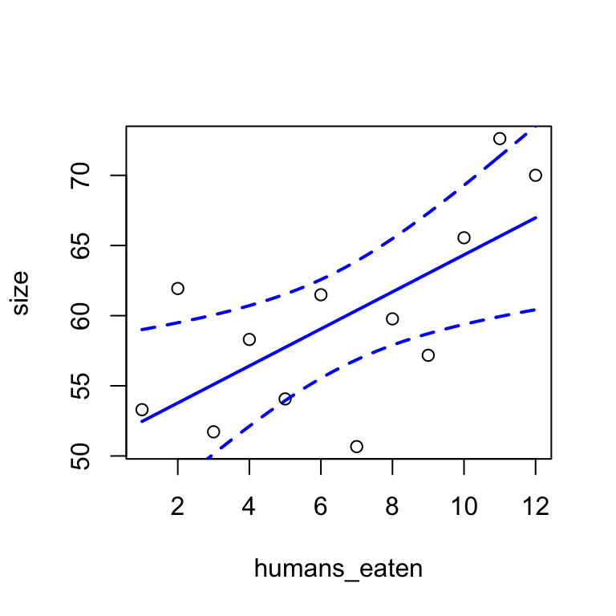

```r
pred <- data.frame(humans_eaten = seq(1, 12, 0.1))
pred <- cbind(pred, predict(mod_stats, newdata = pred, interval = "confidence"))
plot(size ~ humans_eaten, data = Alien)
points(fit ~ humans_eaten, data = pred, lty = 1, lwd = 2, col = "blue", type = "l")
points(upr ~ humans_eaten, data = pred, lty = 2, lwd = 2, col = "blue", type = "l")
points(lwr ~ humans_eaten, data = pred, lty = 2, lwd = 2, col = "blue", type = "l")
```

## Computing 95% CI for the mean response

```r
predict(mod_stats, newdata = data.frame(humans_eaten = 4:5), interval = "confidence")
```

```
##        fit      lwr      upr
## 1 56.41813 52.12033 60.71594
## 2 57.73771 53.94244 61.53298
```

```r
pred <- predict(mod_stats, newdata = data.frame(humans_eaten = 4:5), interval = "confidence", se.fit = TRUE)
rbind(c(pred$fit[1, "fit"] + quantile_min * pred$se.fit[1],
        pred$fit[1, "fit"] + quantile_max * pred$se.fit[1]),
      c(pred$fit[2, "fit"] + quantile_min * pred$se.fit[2],
        pred$fit[2, "fit"] + quantile_max * pred$se.fit[2]))
```

```
##             1        1
## [1,] 52.12033 60.71594
## [2,] 53.94244 61.53298
```

## Computing 95% CI for the mean response

```r
pred$se.fit^2 ## prediction variance
```

```
##        1        2
## 3.720564 2.901357
```

```r
(X <- cbind(c(1, 1), 4:5))  ## design matrix
```

```
##      [,1] [,2]
## [1,]    1    4
## [2,]    1    5
```

```r
(vcov.means <- X %*% vcov(mod_stats) %*% t(X))  ## covariances for predicted values
```

```
##          [,1]     [,2]
## [1,] 3.720564 3.208560
## [2,] 3.208560 2.901357
```

```r
diag(vcov.means)
```

```
## [1] 3.720564 2.901357
```

## Prediction interval

## 95% Prediction Interval

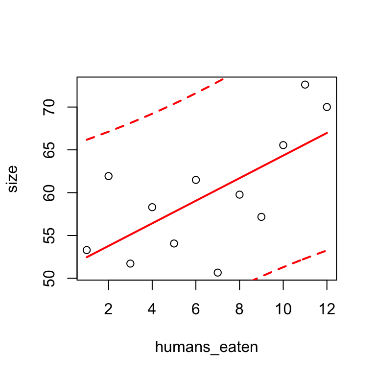

```r
pred <- data.frame(humans_eaten = seq(1, 12, 0.1))
pred <- cbind(pred, predict(mod_stats, newdata = pred, interval = "prediction"))
plot(size ~ humans_eaten, data = Alien)
points(fit ~ humans_eaten, data = pred, lty = 1, lwd = 2, col = "red", type = "l")
points(upr ~ humans_eaten, data = pred, lty = 2, lwd = 2, col = "red", type = "l")
points(lwr ~ humans_eaten, data = pred, lty = 2, lwd = 2, col = "red", type = "l")
```

## Computing 95% PI

```r
pred <- predict(mod_stats, newdata = data.frame(humans_eaten = 4), interval = "prediction", se.fit = TRUE)
pred$fit
```

```
##        fit      lwr      upr
## 1 56.41813 43.61705 69.21921
```

```r
se.pred <- sqrt(pred$se.fit^2 + pred$residual.scale^2)
pred$fit[, "fit"] + quantile_min * se.pred
```

```
## [1] 43.61705
```

```r
pred$fit[, "fit"] + quantile_max * se.pred
```

```
## [1] 69.21921
```

```r
pred$residual.scale^2 == summary(mod_stats)$sigma^2  ## estimate of the error variance
```

```
## [1] TRUE
```

## What you need to remember

- that point estimates are random variables with estimated means and variances
- that estimates are not necessarily independent from each other
- that estimates for \(\beta\) are Gaussian and the estimate of the error variance is gamma distributed
- what 95% Confidence Intervals are
- what the parametric bootstrap is
- that there are 3 main ways to get 95% CI for LM
- that boundaries for 95% CI on \(\widehat{\beta}\) are given by the Student distribution
- what likelihood profiling is
- what statistical coverage is
- what 95% CI on the mean response are
- what 95% Prediction Intervals are

## Table of contents

## The Linear Model: LM

- 2.0 Introduction
- 2.1 Point estimates
- 2.2 Uncertainty in point estimates
- 2.3 Tests
- 2.4 Assumptions and Outliers
- 2.5 Let's practice more